# Лабораторная работа №1

## Ряды Фурье

Предмет: Частотные методы

*Автор: Made by Polyakov Anton, the part of R3236, suir family*

Преподаватель: Алексей Алексеевич Перегудин

[Исходный блокнот, код](https://github.com/GreedlyCore/practice_linear_algebra_labs)

[Онлайн версия](https://colab.research.google.com/drive/1kuKmqM06Q5wRywNUzdm5EYSsG8c2AjST?usp=sharing)

## Навигация

1. Вступление
2. Вспомогательные функции и их описание
3. Содержательная часть
   1. Задание 1.Вещественные функции
   2. Задание 2. Комплексная функция
   3. Задание 3. Рисование
4. Полезные ссылки

## Вступление, приветствие

Сегодня поговорим о рядах Фурье в комплексном и вещественном случае

## Вспомогательные функции и библиотеки, их описание

P.S.1 - Очень часто в коде фигурирует метод *spi.quad* из библиотека scipy, который по сути является взятием определённого интеграла в заданных границах

```python
import matplotlib.pyplot as plt
import numpy as np
import pandas as pd
import scipy.integrate as spi

from svgpathtools import svg2paths, Path
from xml.dom import minidom
from svg.path import parse_path
from svg.path.path import Line
from xml.dom import minidom

import warnings
warnings.filterwarnings('ignore')
```

```python
# изначально не включен в список стандартных библиотек colab'a, если
# вы онлайн версии, то сначала зпустите эту ячейку
# Раскоментить, если в онлайн версии
# !pip install svgpathtools
```

```python
def plot(x, y):
  plt.plot(x, [y(t) for t in x], label='y_exact', color='blue')
  plt.title(f"Original function")
  plt.xlabel('t')
  plt.ylabel('y(t)')
  plt.grid()
  plt.legend(loc='lower right')
  plt.figure(figsize=(6,4))
  plt.show()
```

Функции для вычисления частичных сумм Фурье, случай $\mathbb{R}→\mathbb{R}$

```python
# result --> (a0, 0), (a1, b1)...(aN, bN)
def compute_real_fourier_coeffs(func, N, h, T):
    result = []
    # start EQUALS n
    for n in range(N+1):
        an = (2/T) * spi.quad(lambda t: func(t) * np.cos((2 * np.pi * n * t) / T), h, h+T)[0]
        bn = (2/T) * spi.quad(lambda t: func(t) * np.sin((2 * np.pi * n * t) / T), h, h+T)[0]
        result.append((np.real(an), np.real(bn)))
    return np.array(result)
```

```python
def fit_func_by_fourier_series_with_real_coeffs(t, AB, T):
    result = 0.
    A = AB[:,0]
    B = AB[:,1]
    result +=  A[0]/2.
    for n in range(1, len(AB)):
            result +=  float(A[n]) * np.cos(2. * np.pi * n * t / T) + float(B[n]) * np.sin(2. * np.pi * n * t / T)

    return result
```

```python
def F_N(func, x, N, h, T):
    AB = compute_real_fourier_coeffs(func, N, h, T)
    return fit_func_by_fourier_series_with_real_coeffs(x, AB, T)
```

```python
def plot_real_fourier(func, x, N, h, T):
    for i in N:
        y_approx = F_N(func, x, i, h, T)
        plt.figure(figsize = (6, 4))
        plt.plot(x, [func(t) for t in x], label='exact', color='blue')
        plt.plot(x, y_approx, color='red', label='approx',linestyle='dashed')
        plt.title(f"Real Fourier, N={i}")
        plt.xlabel('t')
        plt.ylabel('y(t)')
        plt.legend(loc='lower right')
        plt.grid()
        plt.show()
```

Функции для вычисления частичных сумм Фурь, случай $\mathbb{C}→\mathbb{R}$

```python
def complex_quad(func, a, b):

    def real_func(x):
        return np.real(func(x))
    def imag_func(x):
        return np.imag(func(x))
    real_integral = spi.quad(real_func, a, b)
    imag_integral = spi.quad(imag_func, a, b)
    return real_integral[0] + 1j*imag_integral[0]
```

```python
#function that computes the complex fourier coefficients c-N,.., c0, .., cN
def compute_complex_fourier_coeffs(func, N, h, T):
    result = []
    for n in range(-N, N+1):
        cn = (1/T) * complex_quad(lambda t: func(t) * np.exp(-1j * 2 * np.pi * n * t / T), h, h+T)
        result.append(cn)
    return np.array(result)
```

```python
def fit_func_by_fourier_series_with_complex_coeffs(t, C, T):
    result = 0. + 0.j
    L = int((len(C) - 1) / 2)
    for n in range(-L, L+1):
        c = C[n+L]
        result +=  c * np.exp(1j * 2. * np.pi * n * t / T)
    return result
```

```python
def G_N(func, x, N, h,T):
    C = compute_complex_fourier_coeffs(func, N, h, T)
    return fit_func_by_fourier_series_with_complex_coeffs(x, C, T)
```

```python
def plot_complex_fourier(func, x, N, h, T):
    for i in N:
        y_approx = G_N(func, x, i, h, T)
        plt.figure(figsize = (6, 4))
        plt.plot(x, [func(t) for t in x], label='exact', color='blue')
        plt.plot(x, y_approx, color='red', label='approx', linestyle='dashed')
        plt.title(f"Complex Fourier, N={i}")
        plt.xlabel('t')
        plt.ylabel('y(t)')
        plt.legend(loc='lower right')
        plt.grid()
        plt.show()
```

Код для красивого вывода коэффициентов фурье (любых матричных структур)

```python
def printBeauty(matrix, Type=complex):
    A = pd.DataFrame(np.round(matrix,4).astype(Type))
    A.columns = ['']*A.shape[1]
    print(A.to_string(index=False))
```

Код для вывода оригинального графика второго задания

```python
def plot_task2_original(func,x):
  plt.figure(figsize=(6, 4))
  plt.plot(func(x).real, func(x).imag, color='blue', label='exact')
  plt.xlabel('Re(f(t))')
  plt.ylabel('Im(f(t))')
  plt.title('Task2 - original plot')
  plt.legend(loc='lower right')
  plt.grid()
  plt.show()
```

Код для подсчёта коэффициентов Фурье в случае $\mathbb{C}→\mathbb{C}$, вывода их в удобном виде

```python
def compute_complex_plane_fourier_coeffs(func, N, h,T):
    result = []
    for n in range(-N, N+1):
        cn = (1./T) * complex_quad(lambda t: func(t) * np.exp(-1j * 2 * np.pi * n * t / T), h, h+T)
        result.append(cn)
    return np.array(result)

def fit_func_by_fourier_series_with_complex_plane_coeffs(t, C, T):
    result = 0. + 0.j
    L = int((len(C) - 1) / 2)
    for n in range(-L, L+1):
        c = C[n+L]
        result +=  c * np.exp(1j * 2. * np.pi * n * t / T)
    return result

def G_N_complex(f,x,N, h,T):
    C = compute_complex_plane_fourier_coeffs(f, N, h,T)
    y_approx = fit_func_by_fourier_series_with_complex_plane_coeffs(x, C, T)

    return [[y.real for y in y_approx], [y.imag for y in y_approx]]
```

```python
def plot_complex_plane_fourier(func, x, N, h, T):
    for i in N:
        G_N = G_N_complex(func,x,i, h,T)
        plt.figure(figsize = (6, 4))
        plt.plot(func(x).real, func(x).imag, label='exact',color='blue')
        plt.plot(G_N[0], G_N[1], color='red', linestyle='dashed',label='approx')
        plt.title('Complex Fourier, R-->C ; ' + f"N={i}")
        plt.xlabel('t')
        plt.ylabel('y(t)')
        plt.legend(loc='lower right')
        plt.grid()
        plt.show()
```

```python
def plot_part(y,x,title,N):
  plt.plot(x, y, label='approx',color='blue')
  plt.title(f"Complex Fourier --> N={N} ; " + title)
  plt.xlabel('t')
  plt.ylabel('y(t)')
  plt.grid()
```

```python
def plot_complex_plane_fourier_part(func, x, N, h,T):
  for n in N:
    G_N = G_N_complex(func, x, n, h,T)
    plt.figure(f"Complex Fourier Parts", figsize=(10,10))
    plt.subplot(2, 2, 1)
    plot_part(G_N[0],x,'Re_G_N(t)',n)
    plt.subplot(2, 2, 2)
    plot_part(func(x).real,x,'Re_f(t)', n)
    plt.subplot(2, 2, 3)
    plot_part(G_N[1],x,'Im_G_N(t)',n)
    plt.subplot(2, 2, 4)
    plot_part(func(x).imag,x,'Im_f(t)',n)


    plt.show()
```

## Содержательная часть

Придумаем числа $a, b, t_0, t_1, t_2$ при условии $a,b>0$, $t_2 > t_1 > t_0 > 0$

```python
a = 1; b = 5; t0 = 1; t1 = 2; t2=4
```

Теперь зададим следующие функции и изучим их детально...

#### Step-функция

$$ T = t_2 - t_0 $$ $$ f(t) = \begin{cases} a, & t\in [t_0,t_1) \\ b, & t\in [t_1,t_2) \end{cases} $$

```python
T1 = t2-t0
step_func = np.vectorize(lambda t: a if t0 <= t% T1 < t1 else b)
```

Соответственно, в нашем случае при подстановке это превратится в ...

$$ T = 3 $$ $$ f(t) = \begin{cases} 1, & t\in [1,2) \\ 5, & t\in [2,4) \end{cases} $$

Зададим область определения по t, построим график

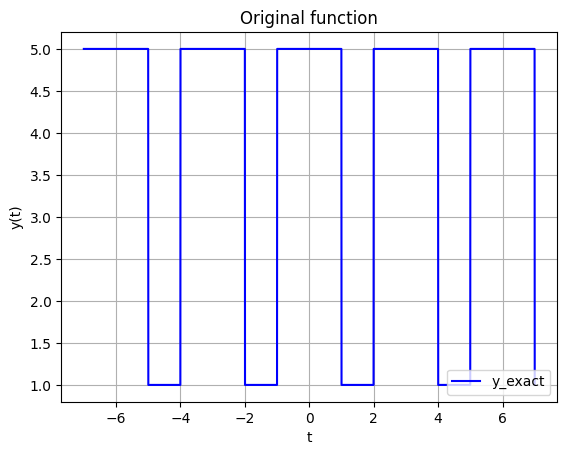

```python
t = np.linspace(-7, 7, 3000)
plot(t, step_func)
```

Посмотрим на частичные суммы следующего вида (вещественные, комплексные)

$$ F_N(t) = \frac{a_0}{2} + \sum^N_{n=1}(a_ncos(\omega_n t) + b_nsin(\omega_n t)),$$ $$ G_N(t) = \sum^N_{n=-N}c_n e^{i\omega_nt},$$ где $\omega_n = 2\pi n/T$

Коэффициенты на произвольном отрезке $[h , h+T]$ будут вычисляться по следующим формулам $$ \begin{aligned} a_n= \frac{2}{T}\int^{h+T}_h \bigg[f(t)cos(\omega_n t)\bigg]dt \\ b_n= \frac{2}{T}\int^{h+T}_h \bigg[f(t)sin(\omega_n t)\bigg]dt \\ c_n= \frac{1}{T}\int^{h+T}_h \bigg[f(t)e^{-i\omega_n t}\bigg]dt \end{aligned} $$

Так как step-функция всегда константа, обозначим в нашем случае за $M$, после вынесем её, в итоге вычисления упрощаются до интеграла тригонометрической функции в разных пределах...

$$ \begin{aligned} a_n = \frac{2}{3} \int^5_0 Mcos(\omega_n t) dt = \frac{2}{3}\bigg[ 5\int^4_2 cos(\frac{2\pi nt}{3})dt + 1\int^2_1 cos(\frac{2\pi nt}{3}) dt \bigg]= \\ \frac{1}{\pi n}(sin(\frac{4\pi n}{3}) - sin(\frac{2\pi n}{3})) + 5( sin(\frac{8\pi n}{3}) - sin(\frac{4\pi n}{3})) \end{aligned} $$

$$ \begin{aligned} b_n = \frac{2}{3} \int^5_0 Msin(\omega_n t) dt = \frac{2}{3}\bigg[ 5\int^4_2 sin(\frac{2\pi nt}{3})dt + 1\int^2_1 sin(\frac{2\pi nt}{3}) dt \bigg]= \\ \frac{1}{\pi n} (cos(\frac{2\pi n}{3}) - cos(\frac{4\pi n}{3})) + 5( cos(\frac{4\pi n}{3}) - cos(\frac{8\pi n}{3})) \end{aligned} $$

Можно отойти от конкретных коэффициентов, тогда получится такой вид

$$ a_n=\frac{1}{\pi n} \bigg[ a(sin(\frac{4\pi n}{3}) - sin(\frac{2\pi n}{3})) + b( sin(\frac{8\pi n}{3}) - sin(\frac{4\pi n}{3})) \bigg] $$

$$ b_n=\frac{1}{\pi n} \bigg[ a(cos(\frac{2\pi n}{3}) - cos(\frac{4\pi n}{3})) + b( cos(\frac{4\pi n}{3}) - cos(\frac{8\pi n}{3})) \bigg] $$

В случае $f:\mathbb{R}\rightarrow\mathbb{R}$ можно облегчить себе жизнь, зная, что $c_i = c_{-i}$ так как компексность должна взаимно уничтожаться, а с веществественными коэффициентами нас ещё связывает следующее соотношение при $n>0$: $$c_n = \frac{a_n - ib_n}{2}$$

Решил не писать отдельную программу, а просто вбить такие формулы в вольфрам и ручками менять $n$, результаты предоставил ниже

Тогда получим следующие коэффициенты

$$ \begin{aligned} a_0 \approx 7.33 && b_0 \approx 0 \\ a_1 \approx 2.2 && b_1 \approx 0 \\ a_2 \approx -1.1 && b_2 \approx 0 \\ c_{-2} \approx -0.551 \\ c_{-1} \approx 1.11 \\ c_{0} \approx 3.66 \\ c_1 \approx 1.11 \\ c_2 \approx -0.551 \end{aligned} $$

Сравним с коэффициентами, которые посчитала программа:

```python
# --> [t0 ; t0+T1]
printBeauty(compute_complex_fourier_coeffs(step_func, 2, t0, T1))
printBeauty(compute_real_fourier_coeffs(step_func, 2, t0, T1), float)
```

```
-0.5513+0.0000j
 1.1027+0.0000j
 3.6667+0.0000j
 1.1027-0.0000j
-0.5513-0.0000j

 7.3333 0.0
 2.2053 0.0
-1.1027 0.0
```

Построим графики $F_N(t)$ и $G_N(t)$ для пяти различных значений $N$, попробуем посравнивать их между собой и с исходным графиком функции $f(t)$

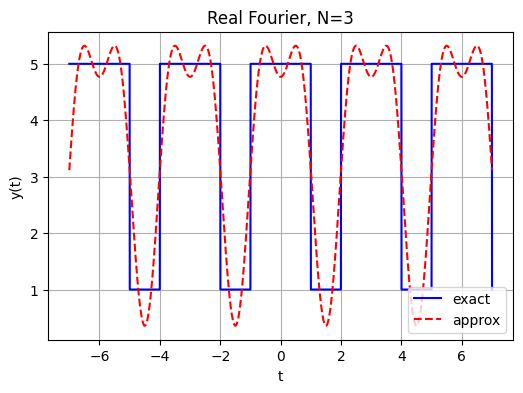

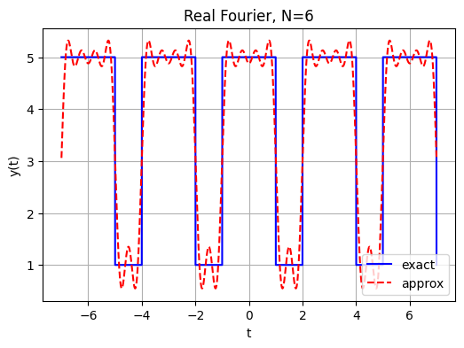

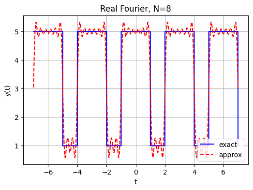

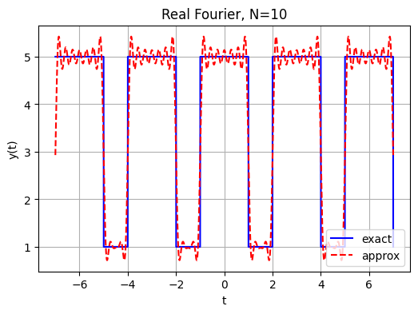

```python
plot_real_fourier(step_func,t,[3,6,8,10],t0,T1)
```

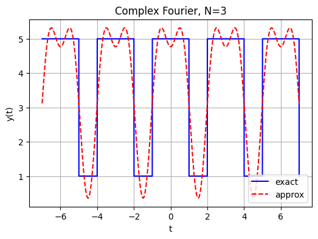

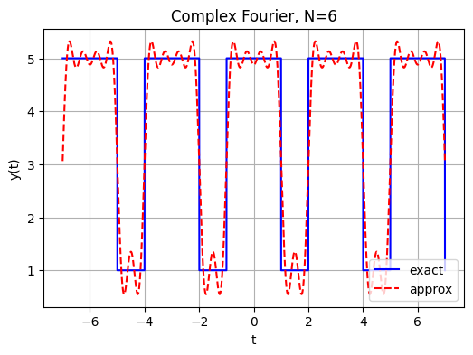

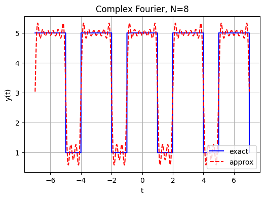

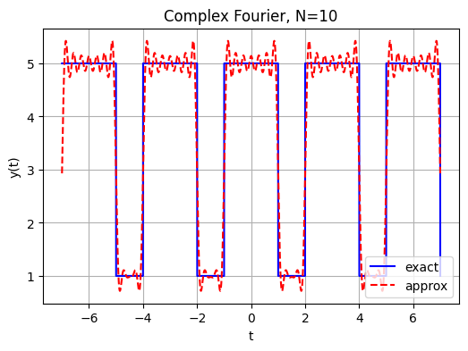

```python
plot_complex_fourier(step_func,t,[3,6,8,10],t0,T1)
```

Нетрудно заметить, что комплексная форма идентична по результатам с вещественной. При увеличении количества элементов частичных сумм, как и следовало ожидать, увеличивается количество участвующих и все более уменьшающихся синусоид, которые уточняют график всё лучше и лучше. На последнем графике уже можно заметить небольшое проявление эффекта "Гиббса", так как step-функция имеет резкий скачок.

Теперь проверим выполнение равенства Парсеваля. Так как у нас ортогональный базис, то в правую часть нужно добавить $2\pi$:

$$ ||f||^2 = 2\pi \sum^{\infty}_{n=-\infty}|c_n|^2 $$

Перепишем равенство в более удобной форме для численного сравнения, не забываем, что проверяется это равенство на $[-\pi;\pi]$

$$ \bigg[\int^{\pi}_{-\pi} |f(x)|^2 dx - 2\pi \sum^{\infty}_{n=-\infty}|c_n|^2 \bigg] \rightarrow 0$$

```python
def compute_complex_fourier_coeffs_sum(func, N, h, T):
    return sum([ np.real(cn)**2 + np.imag(cn)**2 for cn in compute_complex_fourier_coeffs(func, N, h, T)])

def compute_real_fourier_coeffs_sum(func, N, h, T):
    coeffs = compute_real_fourier_coeffs(func, N, h, T)
    number = 0.5 * (coeffs[0][0]**2)
    for an, bn in coeffs[1:]:
        number += an**2 + bn**2

    return np.real(number)


def check_parseval(func, x, h, T, N):
    # norm of the function
    INT = spi.quad(lambda t: func(t)**2, -np.pi, np.pi)[0]
    # squared coeffs
    COEFFS =  2*np.pi * compute_complex_fourier_coeffs_sum(func, N, h, T)
    print(f"N = {N} --> coeff {COEFFS:.5f} and int {INT:.5f}")
    return abs(INT - COEFFS)

def check_parseval2(func, x, h, T, N):
    INT2 = (1/np.pi)*spi.quad(lambda t: func(t)**2, -np.pi, np.pi)[0]
    COEFFS2 = compute_real_fourier_coeffs_sum(func, N, h, T)
    print(f"N = {N} --> coeff {COEFFS2:.5f} and int {INT2:.5f}")
    return abs(INT2-COEFFS2)

T = 2*np.pi
h = -np.pi
for n in [10,20,50,70,90,100]:
    print(f"delta: {check_parseval(step_func, t, h, T,n):.5f}")
```

```
N = 10 --> coeff 107.31795 and int 109.07988
delta: 1.76193
N = 20 --> coeff 108.03250 and int 109.07988
delta: 1.04738
N = 50 --> coeff 108.69692 and int 109.07988
delta: 0.38295
N = 70 --> coeff 108.80859 and int 109.07988
delta: 0.27129
N = 90 --> coeff 108.88050 and int 109.07988
delta: 0.19938
N = 100 --> coeff 108.90247 and int 109.07988
delta: 0.17741
```

Также на просторах интернета можно найти другую форму равенства Парсеваля, для разнообразия применим её к следующим функциям. В коде её реализовали сверху под именем *check_parseval2*

$$ \frac{1}{2}a^2_0 + \sum^\infty_{n=1}(a^2_n+b^2_n) = \frac{1}{\pi}\int_{[-\pi;\pi]}f^2(x)dx $$

| N | Delta | Норма | Сумма коэффициентов |
| --- | --- | --- | --- |
| 500 | 48388 | 109.07 | 48497 |
| 1000 | 90835 | 109.07 | 90944 |
| 2000 | 94243 | 109.07 | 94352 |

#### Чётная функция

$$f(t) = sin^2(2cosx)$$

```python
T2 = 2*np.pi
def even_func(t):
   return ( np.sin(2*np.cos(t)) )**2
```

Зададим область определения по t, построим график

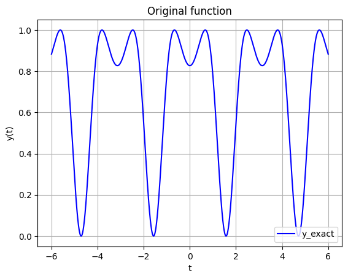

```python
t = np.linspace(-6, 6, 7000)
plot(t,  even_func)
```

Коэффициенты на произвольном отрезке $[h , h+T]$ будут вычисляться по следующим формулам $$ \begin{aligned} a_n= \frac{2}{T}\int^{h+T}_h \bigg[sin^2(2cosx)cos(\omega_n t)\bigg]dt \\ b_n= \frac{2}{T}\int^{h+T}_h \bigg[sin^2(2cosx)sin(\omega_n t)\bigg]dt = 0\\ c_n= \frac{1}{T}\int^{h+T}_h \bigg[sin^2(2cosx)e^{-i\omega_n t}\bigg]dt \end{aligned} $$

Для удобства работы с тригонометрией здесь и далее будем работать с промежутком $[-\pi;\pi]$, а значит можно будет формулы переписать следующим образом:

$$ \begin{aligned} a_n= \frac{1}{\pi}\int^{\pi}_{-\pi} \bigg[sin^2(2cosx)cos(nt)\bigg]dt \\ b_n= \frac{1}{\pi}\int^{\pi}_{-\pi} \bigg[sin^2(2cosx)sin(nt)\bigg]dt = 0\\ c_n= \frac{1}{2\pi}\int^{\pi}_{-\pi} \bigg[sin^2(2cosx)e^{-int}\bigg]dt \end{aligned} $$

Все коэффициенты $b_n$ автоматически будут зануляться вследствии того, что заданная функция - чётная, иными словами - скалярное произведение ортогональных функций (sin & cos) равно нулю.

Коэффициенты посчитать вручную будет проблематично - интеграл неберущийся(по словам wolfram alpha), да и не удивительно, композиция функций обычно к добру не ведёт. Тогда воспользуемся программой: получим семь комплексных коэффициентов и четыре пар вещественных, при $n=\{0,1,2,3\}$

```python
printBeauty(compute_complex_fourier_coeffs(even_func, 3, -np.pi, 2*np.pi))
printBeauty(compute_real_fourier_coeffs(even_func, 3, -np.pi, 2*np.pi), float)
```

```
 0.0000+0.0000j
 0.1821+0.0000j
-0.0000+0.0000j
 0.6986+0.0000j
-0.0000+0.0000j
 0.1821+0.0000j
 0.0000+0.0000j

 1.3971 0.0
-0.0000 0.0
 0.3641 0.0
 0.0000 0.0
```

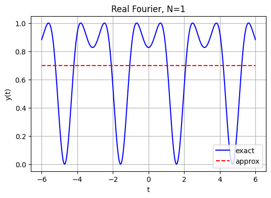

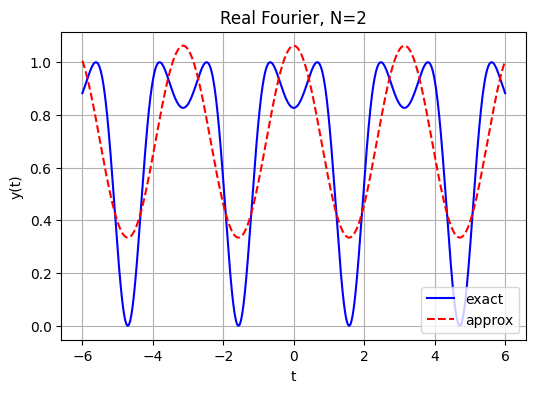

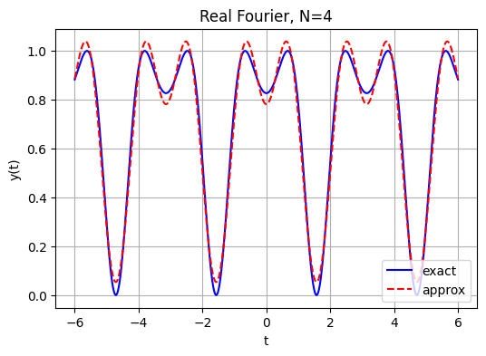

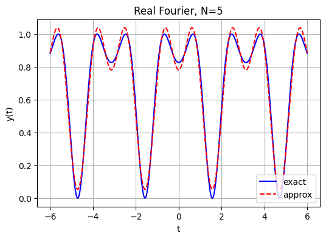

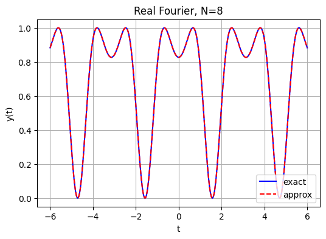

```python
plot_real_fourier(even_func,t,[1,2,4,5,8],-np.pi,2*np.pi)
```

Заметим, что при увеличении $N$ график частичной суммы ряда Фурье довольно быстро приближается к исходной функции. Всего восьми слагаемых хватило, чтобы стать неотличимым от функции.

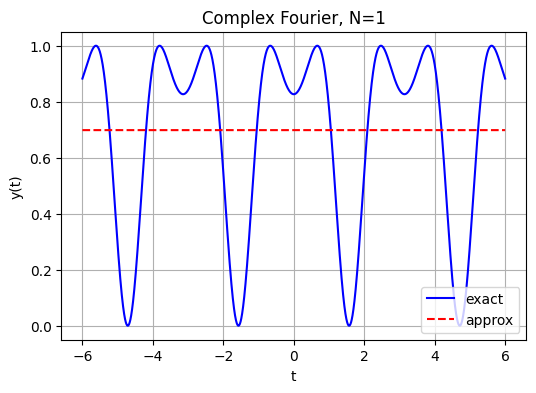

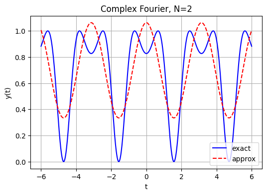

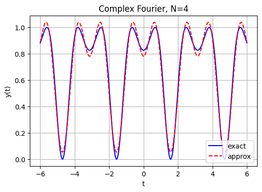

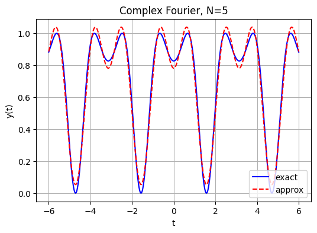

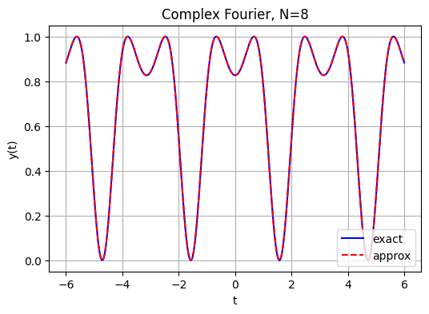

```python
plot_complex_fourier(even_func,t, [1,2,4,5,8],-np.pi,2*np.pi)
```

В комплексном случае получаем аналогичние картинки, приближения идентичны по причине того, что комплексная запись - идентична с вещественной, обобщает её. В дальнейшем мы ещё не раз убедимся в этом, потому что такие совпадения будут везде при $f:\mathbb{R}→\mathbb{R}$.

Проверим равенства Парсеваля по формуле ниже с помощью функции *check_parseval2*

$$ \frac{1}{2}a^2_0 + \sum^\infty_{n=1}(a^2_n+b^2_n) = \frac{1}{\pi}\int_{[-\pi;\pi]}f^2(x)dx $$

```python
for n in [50,70,90,200,500,1000]:
    print(f"delta: {check_parseval2(even_func, t, h, T,n):.4f}")
```

```
N = 50 --> coeff 1.19006 and int 1.19006
delta: 0.0000
N = 70 --> coeff 1.19006 and int 1.19006
delta: 0.0000
N = 90 --> coeff 1.19006 and int 1.19006
delta: 0.0000
N = 200 --> coeff 1.20772 and int 1.19006
delta: 0.0177
N = 500 --> coeff 4.43310 and int 1.19006
delta: 3.2430
N = 1000 --> coeff 32.09752 and int 1.19006
delta: 30.9075
```

Как можно заметить, тенденция с расхождением при увеличении $N$ - сохранилась, что очень печально :(

Однако до $\approx$ сотого слагаемого нам удаётся добиться схождения аж до пяти знаков - не знаю даже радоваться или плакать

[output not shown]

#### Нечётная функция

Возьмём произведение функций, с периодом $T=4\pi$

$$f(t) = cos(2x)sin(x/2)$$

```python
T3 = 4*np.pi
def odd_func(t):
    return np.cos(2*t)*np.sin(t/2)
```

```python
# t = (-14,14, 5000)
t = np.linspace(-6, 6, 7000)
```

На промежутке $[-\pi;\pi]$ коэффициенты ряда Фурье будут вычисляться следующим образом $$ \begin{aligned} a_n= \frac{1}{\pi}\int^{\pi}_{-\pi} \bigg[cos(2x)sin(x/2)cos(nt)\bigg]dt = 0 \\ b_n= \frac{1}{\pi}\int^{\pi}_{-\pi} \bigg[cos(2x)sin(x/2)sin(nt)\bigg]dt \\ c_n= \frac{1}{2\pi}\int^{\pi}_{-\pi} \bigg[cos(2x)sin(x/2)e^{-int}\bigg]dt \end{aligned} $$

В отличии от прошлой функции, здесь мы уже можем вычислить неопредёленный интеграл и получить общий вид для вычисления коэффициентов, но так как по заданию это не требуется, то перейдём сразу к программному методу. Не забываем, что из-за нечётности функции, все коэффциенты $a_n$ зануляться по той же причине, что и в прошлом пункте.

Получим коэффициенты Фурье с помощи программы при $n=\{0,1,2,3\}$

```python
printBeauty(compute_complex_fourier_coeffs(odd_func, 3, -np.pi, 2*np.pi))
printBeauty(compute_real_fourier_coeffs(odd_func, 3, -np.pi, 2*np.pi), float)
```

```
0.0000+0.2444j
0.0000-0.0404j
0.0000-0.1576j
0.0000+0.0000j
0.0000+0.1576j
0.0000+0.0404j
0.0000-0.2444j

0.0  0.0000
0.0 -0.3153
0.0 -0.0808
0.0  0.4887
```

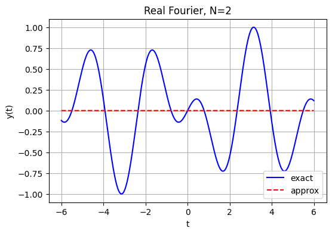

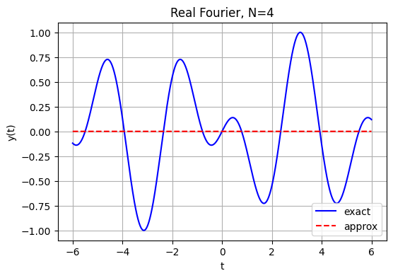

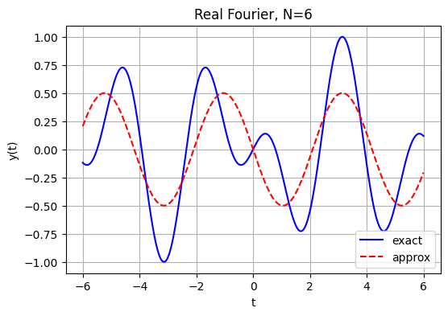

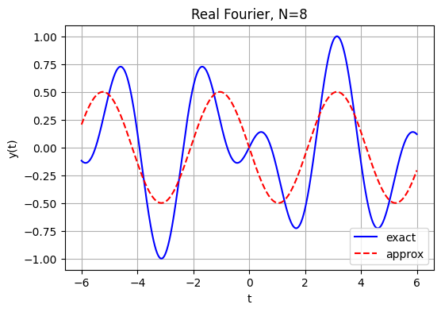

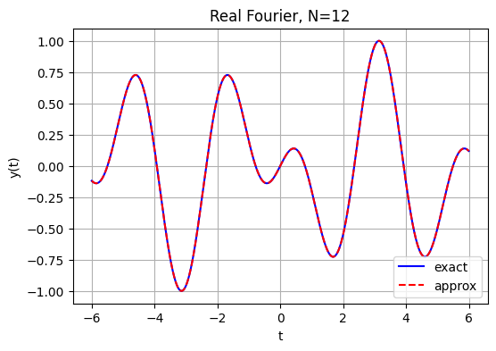

```python
plot_real_fourier(odd_func,t,[2,4,6,8,12],-T3, 2*T3)
```

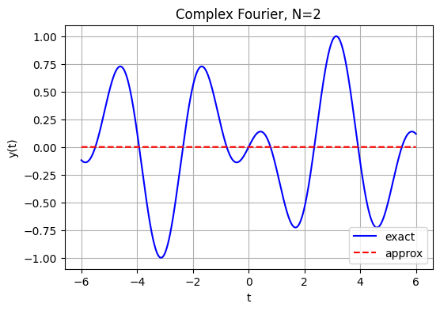

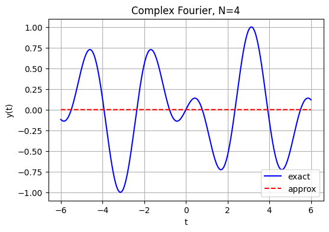

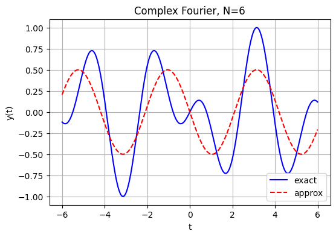

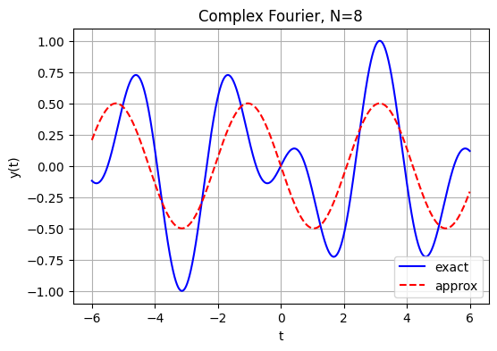

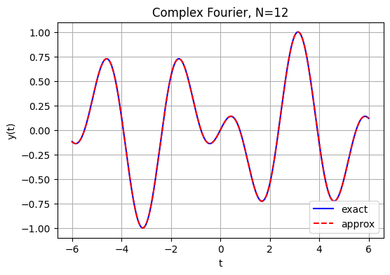

```python
plot_complex_fourier(odd_func,t, [2,4,6,8,12],-T3,2*T3)
```

В Этом случае мы также смогли хорошо приблизиться к исходной функции, но уже потребовалось $N=12$ пар чётных-нечётных гармоник. Вероятно потребовалось больше, потому что функция стала куда сложнее, ведь можно заметить, что до достижения $N=8$ приближения даже и близко не принимало форму оригинальной функции, "думало" долго

Проверим равенства Парсеваля по формуле ниже с помощью функции *check_parseval2*

$$ \frac{1}{2}a^2_0 + \sum^\infty_{n=1}(a^2_n+b^2_n) = \frac{1}{\pi}\int_{[-\pi;\pi]}f^2(x)dx $$

```python
for n in [50,70,90,200,300,500]:
    print(f"delta: {check_parseval2(odd_func, t, h, T,n):.4f}")
```

```
N = 50 --> coeff 0.49197 and int 0.50000
delta: 0.0080
N = 70 --> coeff 0.49425 and int 0.50000
delta: 0.0058
N = 90 --> coeff 0.49552 and int 0.50000
delta: 0.0045
N = 200 --> coeff 0.50423 and int 0.50000
delta: 0.0042
N = 300 --> coeff 1.33376 and int 0.50000
delta: 0.8338
N = 500 --> coeff 1.86551 and int 0.50000
delta: 1.3655
```

В итоге выделим следующие ключевые этапы приближения к равенству:

| N | Delta | Норма | Сумма коэффициентов |
| --- | --- | --- | --- |
| 200 | 0.0042 | 0.5 | 0.5042 |
| 300 | 0.8338 | 0.5 | 1.3337 |
| 500 | 1.3655 | 0.5 | 1.8655 |